# Intratumoral heterogeneity in Glioblastoma

## Load data

We load the scRNA data of MGH106 sample from the public dataset of Gliobastoma (GSE131928)

```r
load(url("https://www.dropbox.com/s/b9udpvhnc2ez9pc/MGH106_data.RData?raw=1"))
```

## Run pipeline

We run the pipeline that performs the classification of malignant and non-malignant cells of the MGH106 sample using 20 cores and requesting analysis of possible subpopulations.

```r
library(SCEVAN)
results <- SCEVAN::pipelineCNA(count_mtx, sample = "MGH106", par_cores = 20, SUBCLONES = TRUE, plotTree = TRUE)
```

```
## [1] " raw data - genes: 23686 cells: 200"
## [1] "1) Filter: cells > 200 genes"
## [1] "2) Filter: genes > 10% of cells"
## [1] "12304 genes past filtering"
## [1] "3) Annotations gene coordinates"
## [1] "found 30 confident non malignant cells"
## [1] "11068 genes annotated"
## [1] "4) Filter: genes involved in the cell cycle"
## [1] "10566 genes past filtering "
## [1] "5)  Filter: cells > 5genes per chromosome "
## [1] "6) Log Freeman Turkey transformation"
## [1] "A total of 200 cells, 10566 genes after preprocessing"
## [1] "7) Measuring baselines (confident normal cells)"
## [1] "8) Smoothing data"
## [1] "9) Segmentation (VegaMC)"
## [1] "10) Adjust baseline"
## [1] "11) plot heatmap"
```

```
## [1] "found 136 tumor cells"
## [1] "time classify tumor cells:  25.8686459064484"
```

```
## [1] "found 3 subclones"
## percentage_cells_subsclone_1 percentage_cells_subsclone_2 percentage_cells_subsclone_3
##                    0.3897059                    0.4191176                    0.1911765
## [1] "Segmentation of subclone :  1"
## [1] "Segmentation of subclone :  2"
## [1] "Segmentation of subclone :  3"
```

```
## $MGH106_subclone1
##     Chr     Start       End Alteration segm.mean
## 16    1 155262868 156430701          2  0.191559
## 36    2 132671799 162371595         -2 -0.220405
## 76    5 132866560 141636870          2  0.147716
## 89    6 129576132 148552050         -2 -0.177527
## 106   8  17643795  28402701          2  0.165937
## 123   9 124777158 128204383         -2 -0.142754
## 158  12  63142759  76853696         -2 -0.147801
## 207  17  29625938  36543435         -2 -0.175544
## 212  17  48830988  51171747          2  0.122247
## 216  17  76389451  78782297         -2 -0.159493
## 232  20   3846799  18316996          2  0.149706
## 247  22  16601887  18914238          2  0.099859
## 120   9  92210207  99970341         -1 -0.063417
## 193  16   2513870  11797267         -1 -0.092448
## 227  19  27684580  34471251          1  0.156300
##
## $MGH106_subclone2
##     Chr     Start       End Alteration segm.mean
## 8     1 151281618 157045370          2  0.188821
## 10    1 206571292 212816626         -2 -0.332493
## 13    2    217730  28870301          2  0.099843
## 20    2  86440647 166149214         -2 -0.219312
## 41    4  26576437  39639090         -2 -0.244094
## 49    4 158672125 174284264          2  0.257183
## 59    5 115124762 139482935          2  0.190356
## 96    8    213186  28755599          2  0.190994
## 100   8  73991352  92103286          2  0.207449
## 128  11  46846412  58578220          2  0.207355
## 163  13 102844844 110870251          2  0.279267
## 190  16  53701692  65126112          2  0.460633
## 199  17  30629680  39730426         -2 -0.264341
## 201  17  40818117  55421992          2  0.275907
## 227  20    270863  34955817          2  0.164324
## 4     1  43164175  78646145          1  0.131879
## 52    5   6599239  32604079          1  0.157283
## 73    6  87470623 107660167         -1 -0.104160
## 75    6 131135666 163315492         -1 -0.122239
## 98    8  38988808  58659844          1  0.153508
```

[output cut: 75 more lines]

```
## MGH106_share1.170  13 106489731 114327328          2  0.138539    1-3    0
## MGH106_share1.182  14  88005124  93116320         -2 -0.153034    1-3    0
## MGH106_share1.184  14 102317377 104768494          2  0.171552    1-3    0
## MGH106_share2.175  15  34851782  43371025         -1 -0.159688    2-3    0
## MGH106_share2.182  15  75353611  78299794          1  0.108603    2-3    0
## MGH106_share2.186  16     46407   2209416          2  0.173651    2-3    0
## MGH106_share1.195  16  28591943  30446181         -2 -0.124534    1-3    0
## MGH106_share1.197  16  55389700  57447528          2  0.284093    1-3    0
## MGH106_share2.197  17  28335602  28903071          2  0.198159    2-3    0
## MGH106_share2.212  19     60951  11784078          2  0.223597    2-1    0
## MGH106_share3.199  19  29698886  36528660          2  0.257608    3-1    0
## MGH106_share2.223  19  44537058  54102692         -2 -0.188791    2-3    0
## MGH106_share1.241  21  17901263  32393026          2  0.172096    1-2    0
## MGH106_share1.246  21  45263928  46665124          2  0.103196    1-3    0
## MGH106_share2.242  22  36189124  39532855         -2 -0.210030    2-1    0
```

```
## [1] "time subclones:  4.65857791105906"
```

## Output

The pipeline returns in *results* a data frame containing for each cell its classification (tumor/normal), whether it has been used as a normal confident cell, and to which clonal subpopulation it belongs.

```r
head(results)
```

```
##               class confidentNormal subclone
## MGH106-P7-E10 tumor            <NA>        1
## MGH106-P2-B01 tumor            <NA>        1
## MGH106-P2-B12 tumor            <NA>        1
## MGH106-P2-H07 tumor            <NA>        2
## MGH106-P2-E09 tumor            <NA>        1
## MGH106-P2-E04 tumor            <NA>        1
```

And creates an output folder containing all segmentation output files and all the plots generated by the analysis:

```r
list.files(path = "./output", pattern = "MGH106")
```

```
##  [1] " MGH106 vega_output"                              " MGH106_SubcloneDiffAnalysis.RData"               " MGH106onlytumor vega_output"
##  [4] "MGH106_Clonal_CN.seg"                             "MGH106_CNAmtx.RData"                              "MGH106_CNAmtxSubclones.RData"
##  [7] "MGH106_count_mtx_annot.RData"                     "MGH106_subclone1_CN.seg"                          "MGH106_subclone2_CN.seg"
## [10] "MGH106_subclone3_CN.seg"                          "MGH106- DEchr12:48926474:50821122_subclones.png"  "MGH106- DEchr3:112585577:198043720_subclones.png"
## [13] "MGH106- DEchr3:409417:14489349_subclones.png"     "MGH106-DEchr1-155320896-160358952_subclones.png"  "MGH106-DEchr1-185045364-212899363_subclones.png"
## [16] "MGH106-DEchr1-29192873-36180849_subclones.png"    "MGH106-DEchr1-74705482-93278730_subclones.png"    "MGH106-DEchr11-111602391-134411918_subclones.png"
## [19] "MGH106-DEchr11-86244544-123063230_subclones.png"  "MGH106-DEchr12_subclones.png"                     "MGH106-DEchr12-109088188-120904371_subclones.png"
## [22] "MGH106-DEchr16-2239395-31917357_subclones.png"    "MGH106-DEchr16-2513870-11797267_subclones.png"    "MGH106-DEchr17-40309192-55325065_subclones.png"
## [25] "MGH106-DEchr17-62423867-79049788_subclones.png"   "MGH106-DEchr17-76389451-78782297_subclones.png"   "MGH106-DEchr19-44165073-57578927_subclones.png"
## [28] "MGH106-DEchr19-47870466-54102692_subclones.png"   "MGH106-DEchr2-130074030-175168382_subclones.png"  "MGH106-DEchr21-25585656-46665124_subclones.png"
## [31] "MGH106-DEchr21-25716503-33643926_subclones.png"   "MGH106-DEchr21-28872191-33643926_subclones.png"   "MGH106-DEchr3_subclones.png"
## [34] "MGH106-DEchr3-112561709-198043720_subclones.png"  "MGH106-DEchr3-158644278-194498364_subclones.png"  "MGH106-DEchr4-108810721-129093607_subclones.png"
## [37] "MGH106-DEchr4-154626945-184221230_subclones.png"  "MGH106-DEchr4-158672125-174284264_subclones.png"  "MGH106-DEchr4-64275257-77952790_subclones.png"
## [40] "MGH106-DEchr5-108747822-149944793_subclones.png"  "MGH106-DEchr5-115124762-139482935_subclones.png"  "MGH106-DEchr5-134928039-149369653_subclones.png"
## [43] "MGH106-DEchr5-98853985-140549578_subclones.png"   "MGH106-DEchr6-109390215-125980244_subclones.png"  "MGH106-DEchr6-125986430-160113507_subclones.png"
## [46] "MGH106-DEchr6-291630-36232790_subclones.png"      "MGH106-DEchr8-126847055-143733801_subclones.png"  "MGH106-DEchr8-213186-28755599_subclones.png"
## [49] "MGH106-DEchr8-73991352-92103286_subclones.png"    "MGH106-DEchr8-75407914-92103286_subclones.png"    "MGH106CloneTree.png"
## [52] "MGH106consensus.png"                              "MGH106heatmap_subclones.png"                      "MGH106heatmap.png"
## [55] "MGH106OncoHeat.png"                               "MGH106OncoHeat2.png"                              "MGH106onlytumorheatmap.png"
## [58] "MGH106pathwayAnalysis_subclones1.png"             "MGH106pathwayAnalysis_subclones2.png"             "MGH106pathwayAnalysis_subclones3.png"
## [61] "MGH106plotCNline.png"                             "MGH106tsne_CNA.png"                               "MGH106tsne_scRNA.png"
```

### Heatmap classification of tumor cells (heatmap.png)

Heatmap of the Copy Number Alteration matrix with classification of non-malignant and malignant cells.

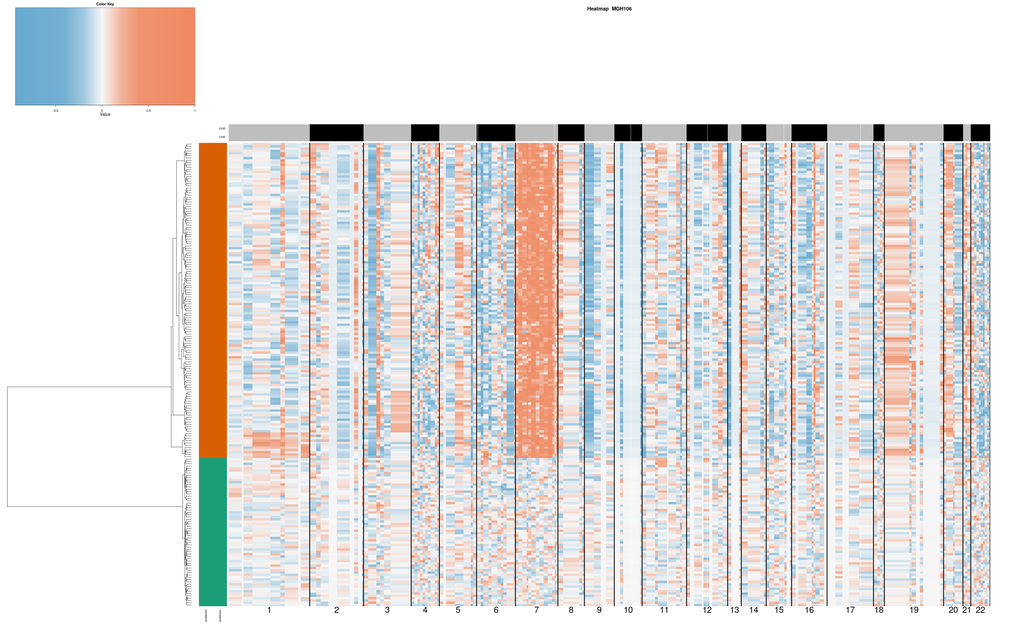

### Heatmap of tumour cell subclones (heatmap_subclones.png)

Heatmap of the Copy Number Alteration matrix with the clonal subpopulations found.

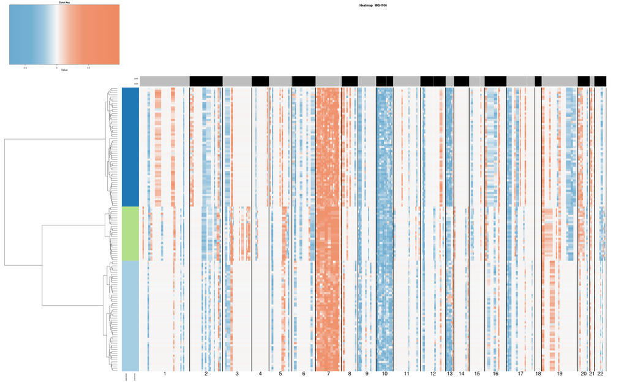

### Clonal tree (CloneTree.png)

Clonal tree inferred from subsclone profiles.

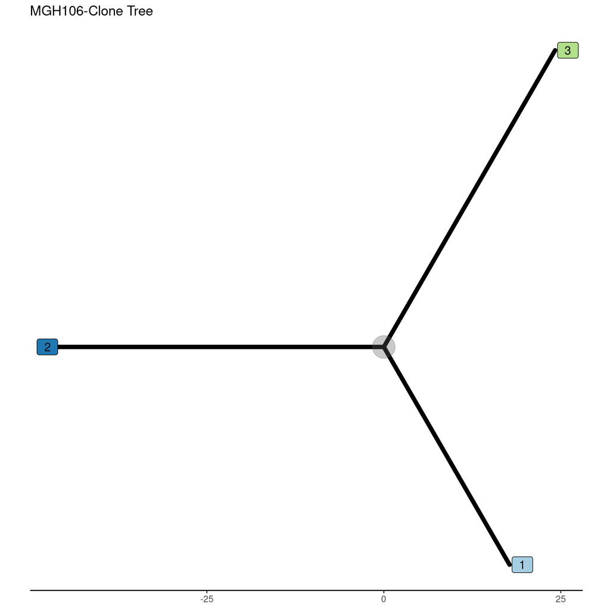

### Consensus plot (consensus.png)

Compact plot of the alterations present in each subpopulation.

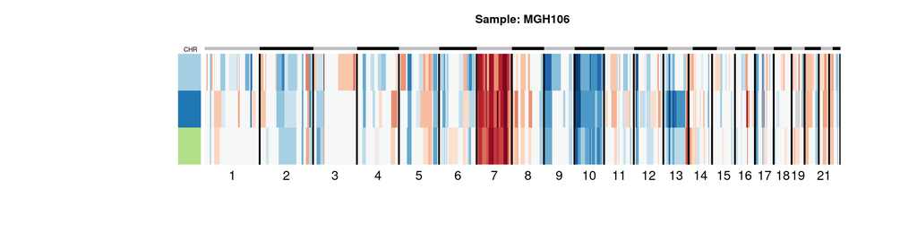

### OncoPrint-like plot (OncoHeat.png)

OncoPrint-like plot that highlighting specific alteration, shared alteration between subclones, or clonal alteration.

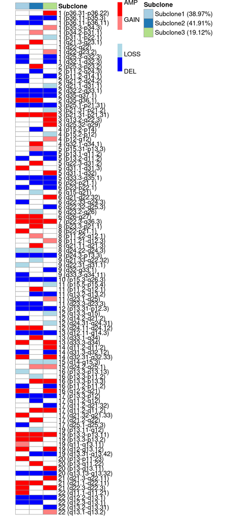

### DE analysis in specific alterations (DEchr*_subclones.png)

Vulcano plot obtained from differential expression analysis of the genes belonging to the specific alterations found.

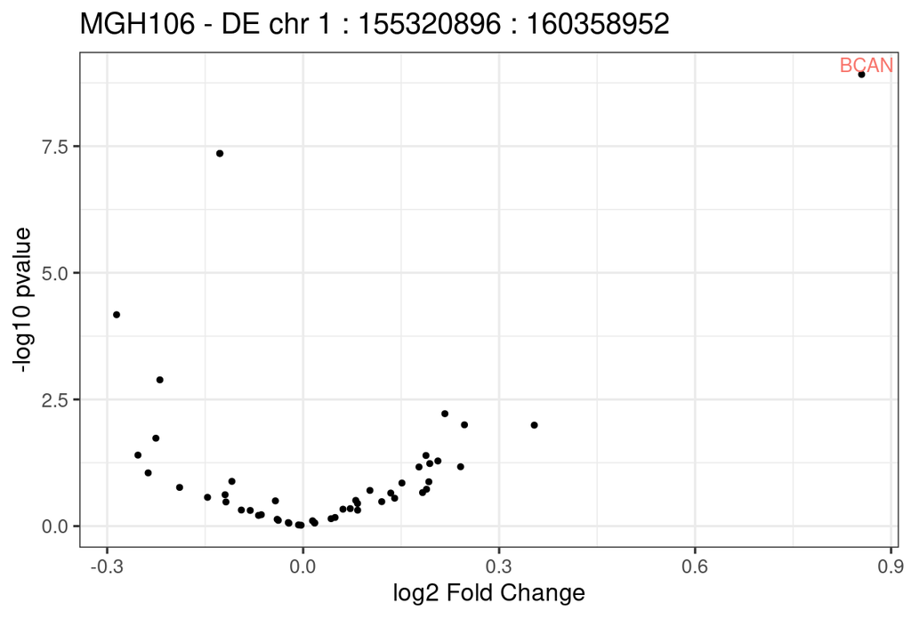

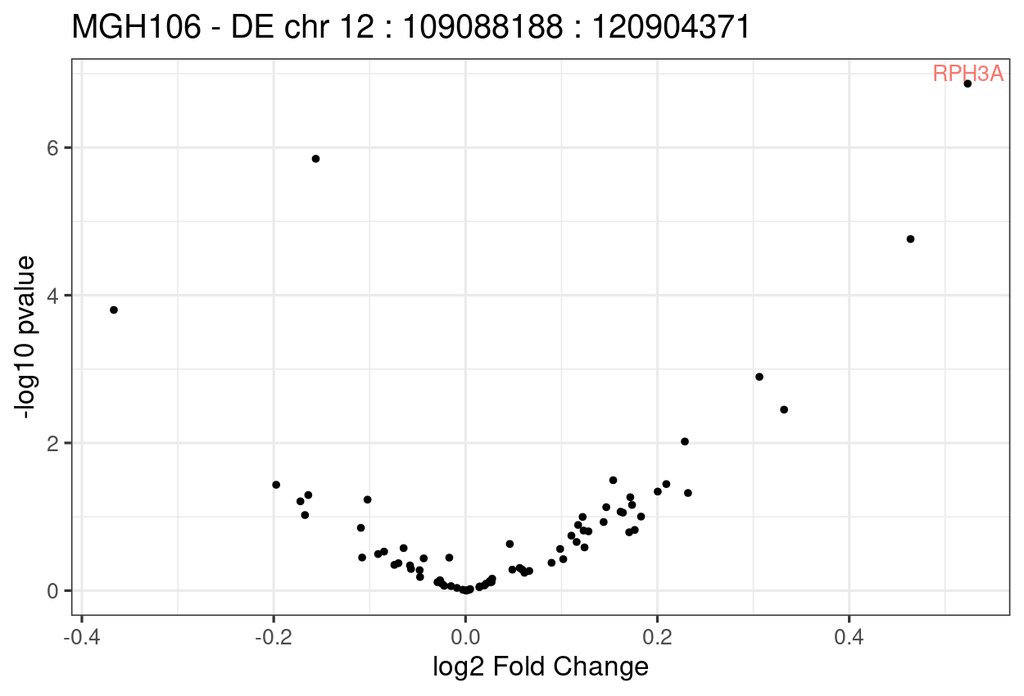

### Pathway Analysis of subclones (pathwayAnalysis_subclones*.png)

REACTOME pathways activity obtained with GSEA for each subclone in contrast to the others for each subclone.

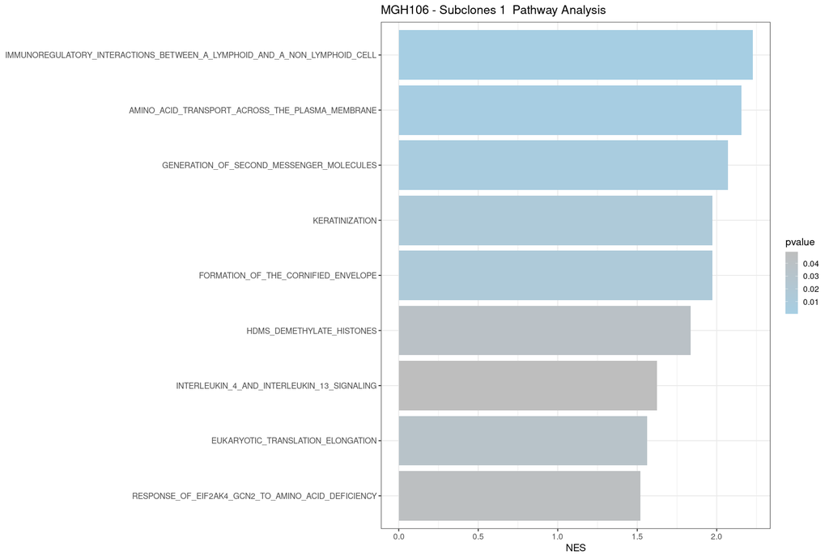

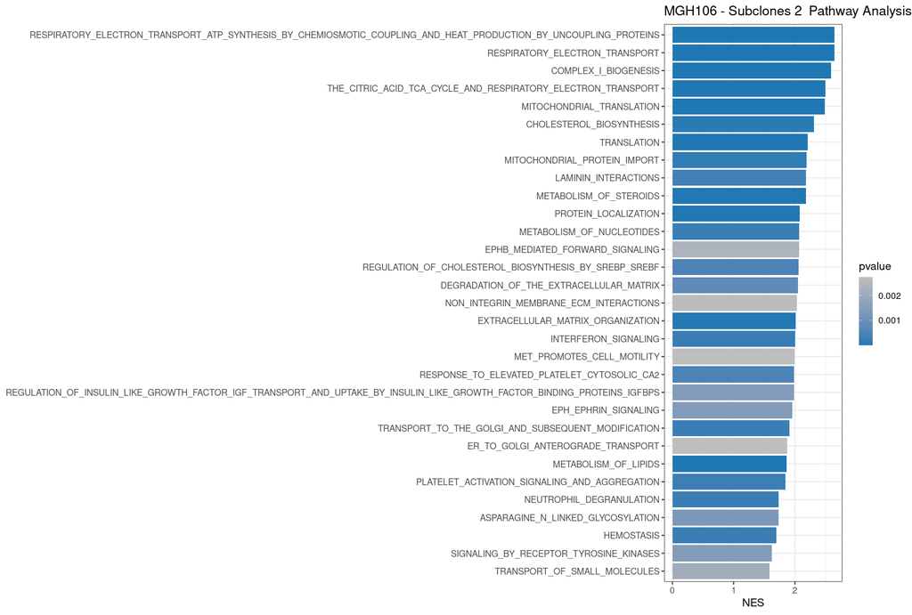

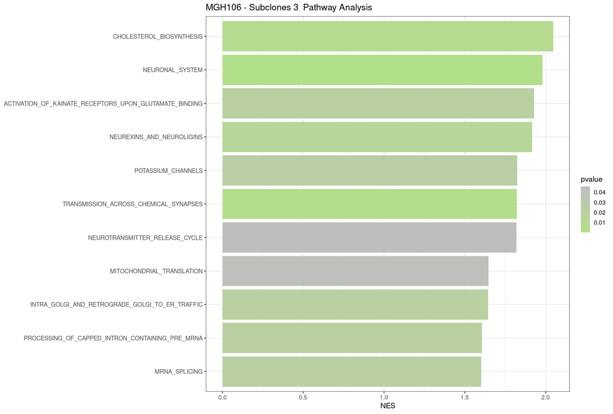